# assignemnt3_task3_jack_miller

Jack Miller

10/23/2021

## Read in the Data

```r
urchins <- read_csv(here("data", "urchins.csv")) %>%
  clean_names
```

# Section 1

### Data Visualization

Histogram of the of the distribution of sizes between purple and red urchins.

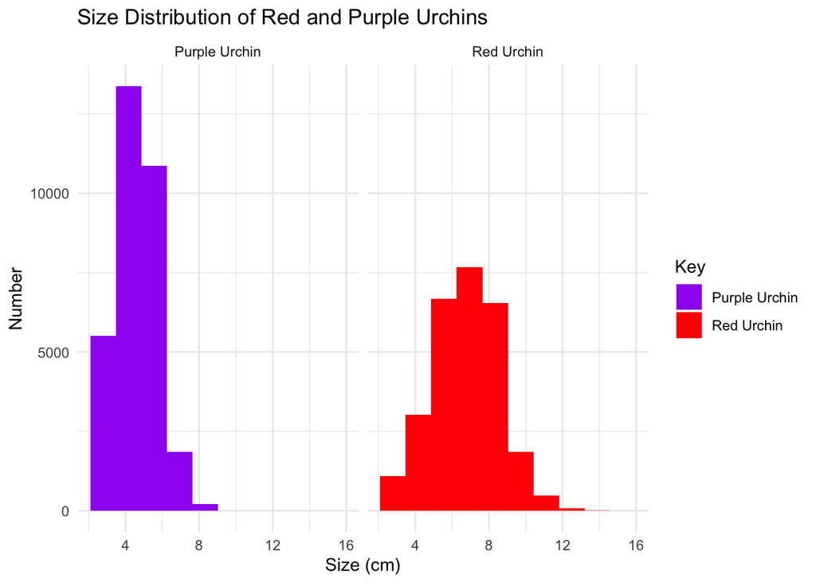

```r
ggplot(data = urchins,
       aes(x = size)) +
  geom_histogram(bins = 10, aes(fill = common_name)) +
  scale_fill_manual(values = c("purple", "red")) +
theme_minimal() +
  labs(x = "Size (cm)",
       y = "Number",
       title = "Size Distribution of Red and Purple Urchins",
       fill = "Key") +
  facet_wrap(~ common_name)
```

**Figure 1. This is a histogram of the size distribution of red and purple urchins, taken from 5 sampling sites along the Santa Barbara coast.**

## Descriptive Statistics Table

Summary statistics table (mean, median, standard deviation, sample size)

```r
summary_statistics <- urchins %>%
  group_by(common_name) %>%
  summarize(mean_size = mean(size),
          median_size = median(size),
          standard_deviation = sd(size),
          sample_size = n())

final_table <- summary_statistics %>%
  kable(caption = "Table 1: Statistics for Sea Urchin Data",
        digits = c(2,2,2,2), # makes it so there is 2 decimals in the table
        col.names = c("Color", # column name
                      "Mean body size (cm)", # column name
                      "Median body size (cm)", # column name
                      "Standard deviation of body size (cm)", # column name
                      "Sample size (n)")) %>%  # column name
    kable_styling(full_width = FALSE)

final_table
```

Table 1: Statistics for Sea Urchin Data

| Color | Mean body size (cm) | Median body size (cm) | Standard deviation of body size (cm) | Sample size (n) |
| --- | --- | --- | --- | --- |
| Purple Urchin | 4.47 | 4.5 | 1.18 | 31805 |
| Red Urchin | 6.78 | 7.0 | 1.89 | 27408 |

## Section 2

Explore purple urchin counts by site and year.

```r
purple_urchins <- urchins %>%
  filter(common_name == "Purple Urchin") %>% # filter to only include purple urchin observations
  mutate(converted_dates = mdy(date)) %>% # convert the date to class "Date"
  mutate(year_date = year(converted_dates)) %>% # create a new column that only contains the year
           mutate(site_full = case_when( # create a new column that contains the full name for the 5 sites
             site == "NAPL" ~ "Naples Reef",
             site == "AQUE" ~ "Arroyo Quemado Reef",
             site == "CARP" ~ "Carpinteria Reef",
             site == "MOHK" ~ "Mohawk Reef",
             site == "IVEE" ~ "Isla Vista Reef"
           ))
```

Table containing e total number of purple urchins observed by site or year

```r
purple_urchin_table <- purple_urchins %>%
  group_by(site_full, year_date) %>% # stores a table of purple urchins observed by site and year
  summarize(count = n())
```

Finalized Graph

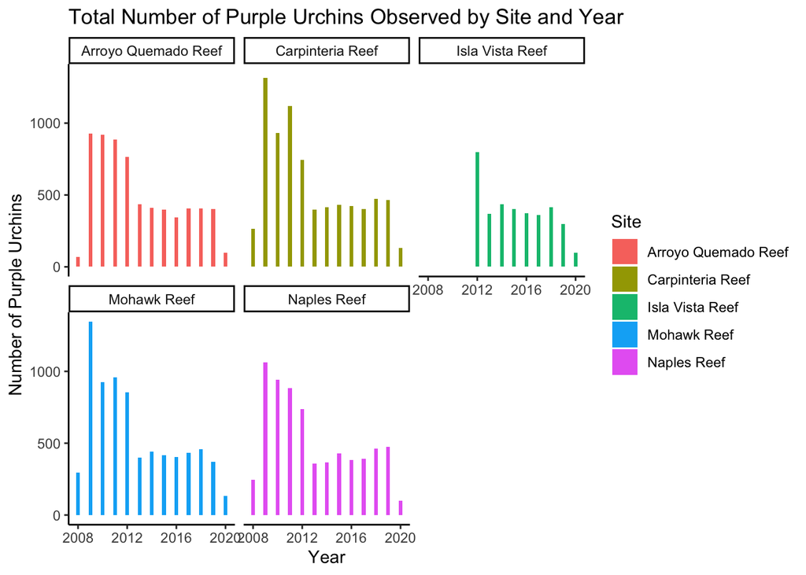

```r
ggplot(data = purple_urchin_table,
       aes(x = year_date, y = count)) +
  geom_col(width = 0.3,
           aes(fill = site_full)) +
  labs(x = "Year", y = "Number of Purple Urchins", title = "Total Number of Purple Urchins Observed by Site and Year", fill = "Site") +
  theme_classic() +
  facet_wrap(~ site_full)
```

**Figure 2. This is a column graph that displays the total number of purple urchins observed at 5 sampling sites along the Santa Barabara Coast.**

This graph reflects changes in the purple urchin population (ie: as time passes, the purple urchin population has been decreasing). I would need to take into account whether the data collection method has remained consistent to determine whether the changes in counts by year are reflective of actual changes in urchin population. Another possible explanation of the changes in purple urchin population include oil spills.